# Analysis

Last updated on 2018-04-18

```r
suppressPackageStartupMessages({
  library(countrycode)
  library(seaaroundus)
  library(tidyverse)
  library(magrittr)
  library(here)
})
```

# Setup

## Load data

```r
FAO_ts <- readRDS(here("data","FAO_data.rds"))
```

```r
FAO_sp_groups <- read.csv(file = here("raw_data","FAO","FAO_spp_groups.csv"), stringsAsFactors = FALSE) %>%
  janitor::clean_names() %>%
  select(species = x3alpha_code, family = family_group, order = order_group) %>%
  mutate(family = taxize::taxize_capwords(family, onlyfirst = T),
         order = taxize::taxize_capwords(order, onlyfirst = T))

# Load FAO species codes lookup table
FAO_sp_codes <- read.csv(file = here("raw_data","FAO","FAO_sp_codes.csv"), stringsAsFactors = FALSE) %>%
  janitor::clean_names() %>%
  select(species = x3alpha_code, common_name = name_en, sci_name = scientific_name) %>%
  left_join(FAO_sp_groups, by = "species") %>%
  mutate(stop = str_locate(string = sci_name, pattern = " ")[, 1],
         genus = substring(text = sci_name, first = 0, last = stop-1)) %>%
  select(order, family, genus, sci_name, common_name, species, family, order)
```

## Load user-defined functions

```r
source(file = here("scripts", "make_robust.R"))
```

# Identify treatment and control groups

We are identifying treatment and control groups based on the following criteria:

- Treated species are those for which aquaculture exists at the genus level and also have an existing fishery
- Control species are thos for which aquaculture has never existed at the genus level

```r
# All genus that have had aquaculture
A <- FAO_ts %>%
  filter(source == "Aquaculture") %>%
  group_by(source, genus) %>%
  tally() %$%
  genus

# Al genus that neve had aquaculture
Fi <- FAO_ts %>%
  filter(!source == "Aquaculture") %>%
  group_by(source, genus) %>%
  tally() %$%
  genus

# Find intersections on the list
treated <- intersect(A, Fi)
control <- Fi[!Fi %in% intersect(A, Fi)]
```

We further reduce these groups and keep the genuses in the top 0.95 <sup>th</sup> percentile in terms of total fisheries production.

```r
# Treated genuses
(select_treated <- FAO_ts %>%
  filter(genus %in% treated) %>%
  filter(!family == "",
         !is.na(genus),
         source == "Catches") %>%
  group_by(genus) %>%
  summarize(total = sum(quantity, na.rm = T)) %>%
  arrange(desc(total)) %>%
  filter(total >= quantile(total, cut)) %>%
  mutate(group = "treated") %>%
  mutate(rank = row_number(desc(total))))
```

```
## # A tibble: 13 x 4
##    genus             total group    rank
##    <chr>             <dbl> <chr>   <int>
##  1 Trachurus     168765239 treated     1
##  2 Gadus         147555299 treated     2
##  3 Thunnus        89606526 treated     3
##  4 Oncorhynchus   42758143 treated     4
##  5 Penaeus        36105813 treated     5
##  6 Pollachius     27794089 treated     6
##  7 Sebastes       27684601 treated     7
##  8 Melanogrammus  27326878 treated     8
##  9 Oreochromis    22720450 treated     9
## 10 Acetes         17415684 treated    10
## 11 Larimichthys   16479078 treated    11
## 12 Lates          14364623 treated    12
## 13 Portunus       14313881 treated    13
```

```r
# Control genuses
(select_control <- FAO_ts %>%
  filter(genus %in% control) %>%
  filter(!family == "",
         !is.na(genus),
         source == "Catches") %>%
  group_by(genus) %>%
  summarize(total = sum(quantity, na.rm = T)) %>%
  arrange(desc(total)) %>%
  filter(total >= quantile(total, cut)) %>%
  mutate(group = "control") %>%
  mutate(rank = row_number(desc(total))))
```

```
## # A tibble: 35 x 4
##    genus          total group    rank
##    <chr>          <dbl> <chr>   <int>
##  1 Engraulis  439366347 control     1
##  2 Theragra   206376746 control     2
##  3 Sardinops  193169063 control     3
##  4 Clupea     166666086 control     4
##  5 Scomber    141393874 control     5
##  6 Sardinella  91180806 control     6
##  7 Merluccius  77165939 control     7
##  8 Katsuwonus  76692197 control     8
##  9 Mallotus    73488238 control     9
## 10 Sardina     57669672 control    10
## # ... with 25 more rows
```

We use the norrowed-down list of genuses to filter our entire data. The first step is to identify the year in which aquaculture began for each of the treated genuses. Since we need to have data predating the start of aquaculture to meassure the change in trend, we only keep species that have had at least 5 years of pre-treatment data.

```r
(aq_treated_genus <- FAO_ts %>%
  filter(genus %in% select_treated$genus,
         source == "Aquaculture") %>%
  group_by(genus, year) %>%
  summarize(quantity = sum(quantity)) %>%
  ungroup() %>%
  group_by(genus) %>%
  summarize(year_start = min(year)) %>%
  ungroup() %>%
  arrange(year_start) %>%
  filter(year_start > 1955))
```

```
## # A tibble: 10 x 2
##    genus         year_start
##    <chr>              <dbl>
##  1 Portunus            1961
##  2 Lates               1963
##  3 Trachurus           1970
##  4 Acetes              1973
##  5 Thunnus             1984
##  6 Gadus               1987
##  7 Sebastes            1996
##  8 Larimichthys        2003
##  9 Melanogrammus       2003
## 10 Pollachius          2006
```

Let’s look at the distribution of the initial years

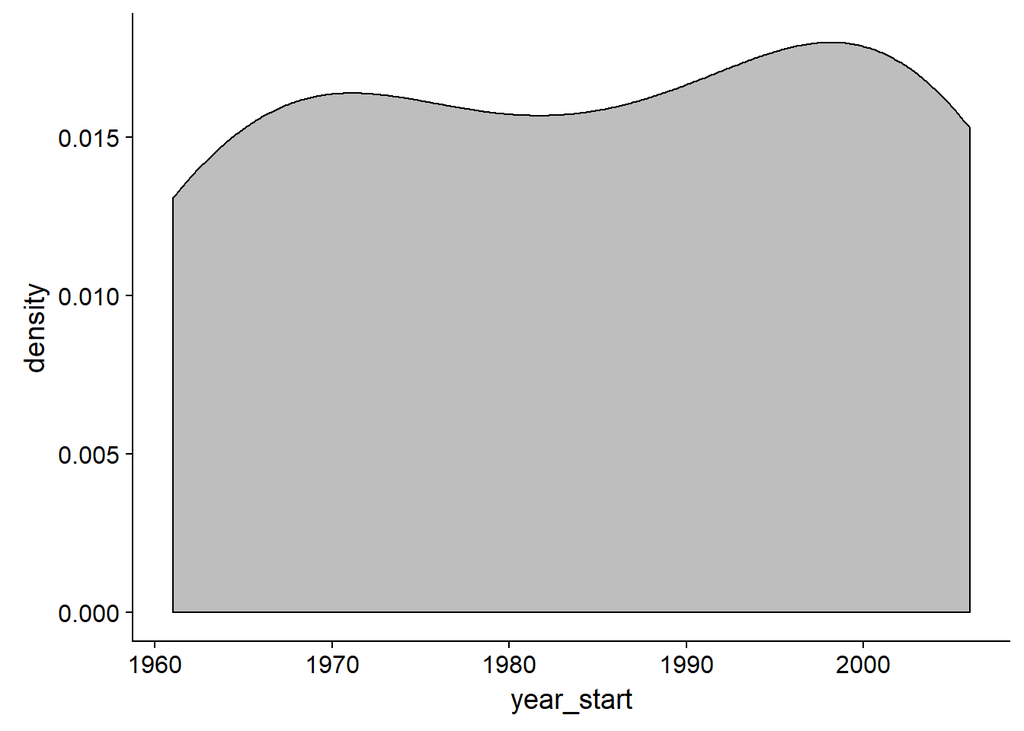

```r
ggplot(aq_treated_genus, aes(x = year_start)) +
  geom_density(fill = "grey") +
  cowplot::theme_cowplot()
```

From the above, we see that the mean year when treatment began is 1984.6 $\pm$ 17.13476 (mean $\pm$ 1 SD).

```r
# Make control

# Define pre - post cutoff as mean of treatment

pre_post <- round(mean(aq_treated_genus$year_start)) #Define a better way of year-start

control_group <- FAO_ts %>%
  filter(genus %in% select_control$genus,
         source == "Catches") %>%
  group_by(year, iso, genus, species, sci_name) %>%
  summarize(quantity = sum(quantity),
            min_year = min(year)) %>%
  ungroup() %>%
  mutate(group = 0,
         year_start = pre_post,
         post = ifelse(year <= year_start, 0, 1),
         aquaculture = 0) %>%
  select(year, country = iso, genus, species, sci_name, quantity, aquaculture, post, group, year_start)

# Make treatment
treatment_group_ac <- FAO_ts %>%
  filter(genus %in% aq_treated_genus$genus,
         source == "Aquaculture") %>%
  group_by(year, genus) %>%
  summarize(aquaculture = sum(quantity)) %>%
  ungroup()

treatment_group <- FAO_ts %>%
  filter(genus %in% aq_treated_genus$genus,
         source == "Catches") %>%
  group_by(year, iso, genus, species, sci_name) %>%
  summarize(quantity = sum(quantity)) %>%
  ungroup() %>%
  left_join(aq_treated_genus, by = "genus") %>%
  mutate(group = 1,
         post = ifelse(year <= year_start, 0, 1)) %>%
  left_join(treatment_group_ac, by = c("year", "genus")) %>%
  select(year, country = iso, genus, species, sci_name, quantity, aquaculture, post, group, year_start)
```

Now we put these data together

```r
data_for_model <- rbind(control_group, treatment_group) %>%
  filter(!country == "")
```

And save it:

```r
write.csv(x = data_for_model,
          file = here("data", "data_for_model.csv"),
          row.names = F)
```

# Analyses

## Visualize the data

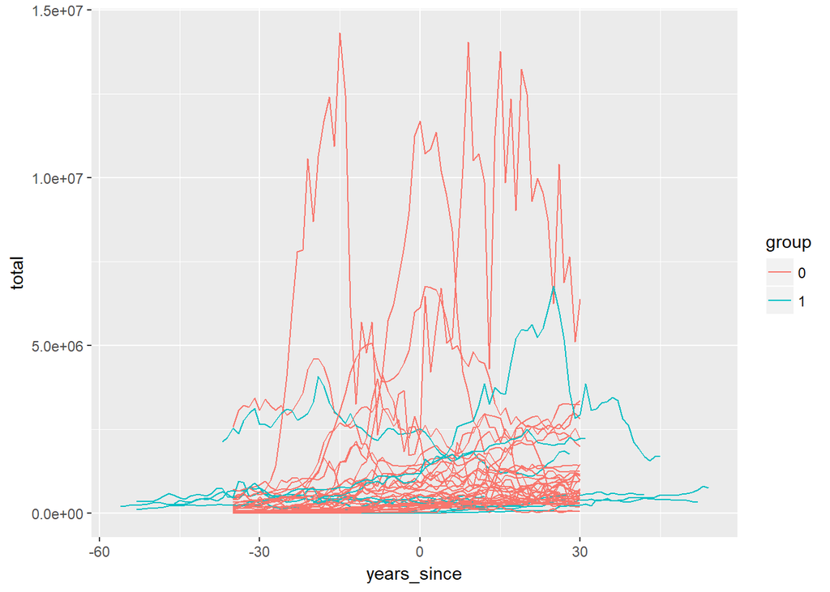

```r
data_for_model %>%
  # filter(group == 0) %>%
  mutate(years_since = year - year_start,
         group = as.factor(group)) %>%
  group_by(years_since, group, genus) %>%
  summarize(total = sum(quantity, na.rm = T)) %>%
  ungroup() %>%
  ggplot(aes(x = years_since, y = total, color = group, group = genus)) +
  geom_line()
```

## Comments by Kyle:

The diff-in-diff model you presented in class looked something like:

$$y_{it} = \beta_1 Salmon_i * Post_t + \beta_2Salmon_i + \beta_3Post_t + e_{it}$$

where Salmon_i is a dummy equal to one if i refers to a salmon and Post_t is a dummy equal to one if t is after the introduction of salmon aquaculture. This estimator basically fits a constant effect for all post aquaculture years.

$$ln(quantity_{it}) = \beta_1 G_i\times Post_t + \beta_2G_i + \beta_3Post_t + \sum_{f = 1}^{30}\gamma_fF_f + ln(aquacultur+1) + \sum_{t = 1}^T\Omega_tt+ \epsilon_{it}$$

We now have the data to fit the models above:

```r
lm(log(quantity) ~ group*post + genus + country -1, data_for_model) %>%
  stargazer::stargazer(se = list(make_robust(., cluster = "genus")),
                       t.auto = T,
                       p.auto = T,
                       single.row = T,
                       omit = c("genus", "year", "country"),
                       header = F,
                       type = "html")
```

|  | *Dependent variable:* |
| --- | --- |
|  | log(quantity) |
| group | 8.262 |
| post | -0.122 |
| group:post | -0.032 |
| Observations | 70,863 |
| R<sup>2</sup> | 0.914 |
| Adjusted R<sup>2</sup> | 0.913 |
| Residual Std. Error | 2.349 (df = 70631) |
| F Statistic | 3,218.995*** (df = 232; 70631) |
| *Note:* | p<0.1; p<0.05; p<0.01 |

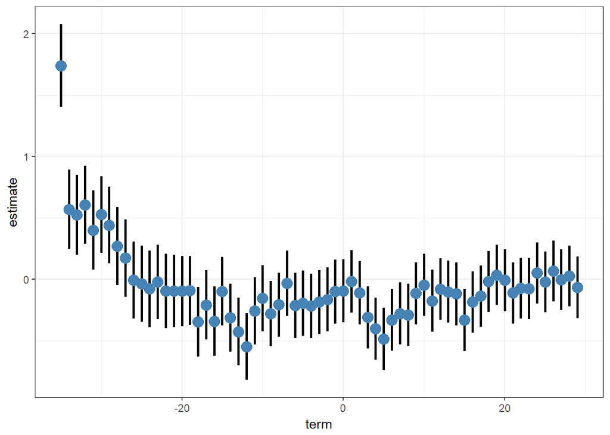

```r
data_for_model %>%
  mutate(years_since = as.factor(as.integer(year - year_start)),
                          group = as.factor(group)) %>%
  lm(log(quantity) ~ group * years_since, data = .) %>%
  lmtest::coeftest(vcov = sandwich::vcovHC(x = ., vcov = "H2")) %>%
  broom::tidy() %>%
  filter(grepl(pattern = "group1:years_", x = term)) %>%
  mutate(term = as.numeric(gsub(
                          pattern = "group1:years_since",
                          replacement = "",
                          x = term))) %>%
  ggplot(aes(x = term, y = estimate)) +
  geom_errorbar(aes(ymin = estimate - std.error, ymax = estimate + std.error), width = 0, size = 1) +
  geom_point(color = "steelblue", size = 4) +
  theme_bw()
```

As an alternative, you can do what’s called an “event study” plot where you now have:

$$y_{it} = \sum_{\frac{-12<s<30}{s \neq 0}} \beta_s * Salmon_i * event_s + \beta_2*Salmon_i + \beta_3*Post_t + e_{it}$$

$$ln(Q) = \sum_{\frac{-12<s<30}{s \neq 0}} \beta_s G_i\times event_s + \beta_2G_i + \beta_3Post_t + \sum_{f = 1}^{30}\gamma_fF_f + ln(aquacultur+1) + \sum_{t = 1}^T\Omega_tt+ \epsilon_{it}$$

where now $event_s$ are dummies that equal one for each year before and after the introduction of aquaculture. The year of the introduction will be the omitted variable. You effective estimate a time varying effect before and after aquaculture’s introduction. The idea here is to allow the data to tell you what that response is over time. The coefficients prior to the treatment will serve as tests for differential pre-trends between lobster and salmon prior to the salmon aquaculture introduction. I want you guys to plot the $\beta_s$ coefficients and its associated standard errors.

```r
T0 <- tibble(term = "group:T0", estimate = 0, std.error = 0, statistic = 0, p.value = NA, year = 0)

data_for_model %>%
  mutate(year = year - year_start,
         Tm12 = (year == -12)*1,
         Tm11 = (year == -12)*1,
         Tm10 = (year == -10)*1,
         Tm9 = (year == -9)*1,
         Tm8 = (year == -8)*1,
         Tm7 = (year == -7)*1,
         Tm6 = (year == -6)*1,
         Tm5 = (year == -5)*1,
         Tm4 = (year == -4)*1,
         Tm3 = (year == -3)*1,
         Tm2 = (year == -2)*1,
         Tm1 = (year == -1)*1,
         T0 = (year == 0)*1,
         T1 = (year == 1)*1,
         T2 = (year == 2)*1,
         T3 = (year == 3)*1,
         T4 = (year == 4)*1,
         T5 = (year == 5)*1,
         T6 = (year == 6)*1,
         T7 = (year == 7)*1,
         T8 = (year == 8)*1,
         T9 = (year == 9)*1,
         T10 = (year == 10)*1,
         T11 = (year == 11)*1,
         T12 = (year == 12)*1,
         T13 = (year == 13)*1,
         T14 = (year == 14)*1,
         T15 = (year == 15)*1,
         T16 = (year == 16)*1,
         T17 = (year == 17)*1,
         T18 = (year == 18)*1,
         T19 = (year == 19)*1,
         T20 = (year == 20)*1,
         T21 = (year == 21)*1,
         T22 = (year == 22)*1,
         T23 = (year == 23)*1,
         T24 = (year == 24)*1,
         T25 = (year == 25)*1,
         T26 = (year == 26)*1,
         T27 = (year == 27)*1,
         T28 = (year == 28)*1,
         T29 = (year == 29)*1,
         T30 = (year == 30)*1) %>%
  filter(dplyr::between(year, -12, 30)) %>%
  lm(formula = log(quantity) ~ group*(Tm12 + Tm11 + Tm10 + Tm9 + Tm8 + Tm7 + Tm6 + Tm5 + Tm4 + Tm3 + Tm2 + Tm1 +T1 + T2 + T3 + T4 + T5 + T6 + T7 + T8 + T9 + T10 + T11 + T12 + T13 + T14 + T15 + T16 + T17 + T18 + T10 + T20 + T21 + T22 + T24 + T25 + T26 +T27 + T28 + T29 + T30) + group +  post + genus + as.factor(year) -1, data = .) %>%
  lmtest::coeftest(plm::vcovHC(., type = "HC2", cluster = "genus")) %>%
  broom::tidy() %>%
  filter(grepl(pattern = "(group:T)", x = term)) %>%
  mutate(year = substring(term, 8,10),
         year = gsub(pattern = "m", replacement = "-", year),
         year = as.numeric(year)) %>%
  rbind(T0) %>%
  ggplot(aes(x = year, y = estimate)) +
  geom_ribbon(aes(ymin = estimate - std.error, ymax = estimate + std.error), fill = "gray", alpha = 0.5) +
  geom_line(color = "red", size = 1) +
  cowplot::theme_cowplot() +
  geom_hline(yintercept = 0, linetype = "dashed") +
  labs(x = "years since aquaculture", y = bquote(beta[s]))
```

[output not shown]

- Re do with 90% of cumulative production Aq instead of 90th percentile

```r
# Treated genuses
(select_treated_2 <- FAO_ts %>%
  filter(genus %in% treated) %>%
  filter(!family == "",
         !is.na(genus),
         source == "Catches") %>%
  group_by(genus) %>%
  summarize(total = sum(quantity, na.rm = T)) %>%
  ungroup() %>%
  mutate(total = total/sum(total)) %>%
  arrange(desc(total)) %>%
  mutate(cum_total = cumsum(total)) %>%
  filter(cum_total <= 0.9) %>%
  mutate(group = "treated") %>%
  mutate(rank = row_number(desc(total))))
```

```
## # A tibble: 42 x 5
##    genus          total cum_total group    rank
##    <chr>          <dbl>     <dbl> <chr>   <int>
##  1 Trachurus     0.184      0.184 treated     1
##  2 Gadus         0.161      0.344 treated     2
##  3 Thunnus       0.0975     0.442 treated     3
##  4 Oncorhynchus  0.0465     0.488 treated     4
##  5 Penaeus       0.0393     0.528 treated     5
##  6 Pollachius    0.0302     0.558 treated     6
##  7 Sebastes      0.0301     0.588 treated     7
##  8 Melanogrammus 0.0297     0.618 treated     8
##  9 Oreochromis   0.0247     0.642 treated     9
## 10 Acetes        0.0190     0.661 treated    10
## # ... with 32 more rows
```

```r
# Control genuses
(select_control_2 <- FAO_ts %>%
  filter(genus %in% control) %>%
  filter(!family == "",
         !is.na(genus),
         source == "Catches") %>%
  group_by(genus) %>%
  summarize(total = sum(quantity, na.rm = T)) %>%
  ungroup() %>%
  mutate(total = total/sum(total)) %>%
  arrange(desc(total)) %>%
  mutate(cum_total = cumsum(total)) %>%
  filter(cum_total <= 0.9) %>%
  mutate(group = "control") %>%
  mutate(rank = row_number(desc(total))))
```

```
## # A tibble: 47 x 5
##    genus       total cum_total group    rank
##    <chr>       <dbl>     <dbl> <chr>   <int>
##  1 Engraulis  0.178      0.178 control     1
##  2 Theragra   0.0836     0.262 control     2
##  3 Sardinops  0.0783     0.340 control     3
##  4 Clupea     0.0675     0.407 control     4
##  5 Scomber    0.0573     0.465 control     5
##  6 Sardinella 0.0369     0.502 control     6
##  7 Merluccius 0.0313     0.533 control     7
##  8 Katsuwonus 0.0311     0.564 control     8
##  9 Mallotus   0.0298     0.594 control     9
## 10 Sardina    0.0234     0.617 control    10
## # ... with 37 more rows
```

Let’s look at the cumulative weights:

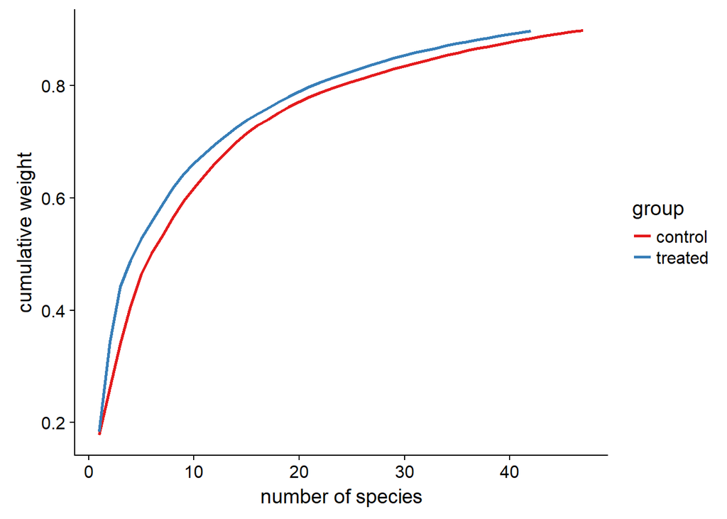

```r
rbind(select_control_2, select_treated_2) %>%
  ggplot(aes(x = rank, y = cum_total, color = group)) +
  geom_line(size = 1) +
  cowplot::theme_cowplot() +
  scale_color_brewer(palette = "Set1") +
  labs(x = "number of species", y = "cumulative weight")
```

```r
# number of species in control families

FAO_sp_codes %>%
  filter(genus %in% select_control_2$genus) %>%
  group_by(genus, species) %>%
  tally() %>%
  select(-n) %>%
  group_by(genus) %>%
  tally() %$%
  sum(n) -> n_sp_control_2

# number of species in treated families

FAO_sp_codes %>%
  filter(genus %in% select_treated_2$genus) %>%
  group_by(genus, species) %>%
  tally() %>%
  select(-n) %>%
  group_by(genus) %>%
  tally() %$%
  sum(n) -> n_sp_treated_2
```

We can see that by using the top 90 species, our number of treated species goes from 193 to 563, and the number of control species goes from 204 to 275

```r
(aq_treated_genus_2 <- FAO_ts %>%
  filter(genus %in% select_treated_2$genus,
         source == "Aquaculture") %>%
  group_by(genus, year) %>%
  summarize(quantity = sum(quantity)) %>%
  ungroup() %>%
  group_by(genus) %>%
  summarize(year_start = min(year)) %>%
  ungroup() %>%
  arrange(year_start) %>%
  filter(year_start > 1955))
```

```
## # A tibble: 28 x 2
##    genus        year_start
##    <chr>             <dbl>
##  1 Pagrus             1958
##  2 Portunus           1961
##  3 Lates              1963
##  4 Ruditapes          1964
##  5 Epinephelus        1970
##  6 Patinopecten       1970
##  7 Trachurus          1970
##  8 Acetes             1973
##  9 Panulirus          1976
## 10 Lutjanus           1978
## # ... with 18 more rows
```

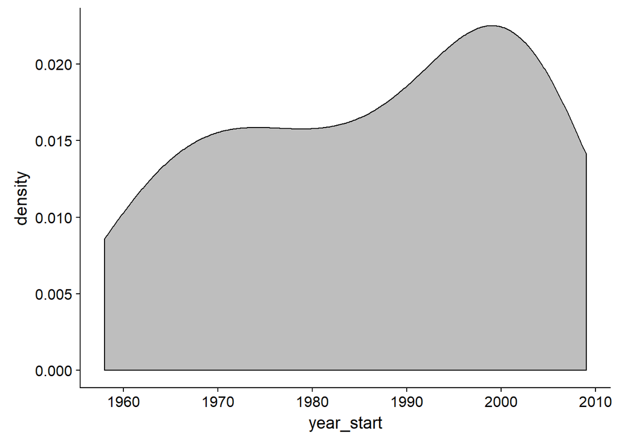

```r
ggplot(aq_treated_genus_2, aes(x = year_start)) +
  geom_density(fill = "grey") +
  cowplot::theme_cowplot()
```

- Add price data from SAU
- Add biomass from stock-assessement from RAM